# Untitled1 slides

```python
import numpy as np
import theano
import theano.tensor as T
%matplotlib inline
import matplotlib.pyplot as plt
```

What we want to get: $$ g(\mathbf{x};\theta,\boldsymbol{\sigma},\boldsymbol{\mu}) = \exp\left(-{\left\| (\mathbf{x} - \boldsymbol{\mu}) \right\|}^2\right) $$

```python
rows = 32
cols = 32
n_hidden = rows * cols
points = np.dstack(np.meshgrid(np.arange(cols),np.arange(rows))).reshape(n_hidden,2)
print points
print points.shape
```

```
[[ 0  0]
 [ 1  0]
 [ 2  0]
 ...,
 [29 31]
 [30 31]
 [31 31]]
(1024, 2)
```

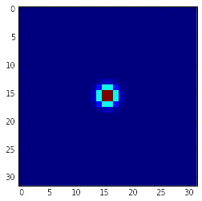

```python
mean = np.array([15.5,15.5],dtype=np.float32) # shape is (2,)
values = np.exp(-np.sum(0.5 * (points - mean)**2,axis=1)) # notice formula from before

plt.imshow(values.reshape(32,32),interpolation='none')
```

The idea is to have many such surfaces, and you can use some broadcasting stunts to pull it off.

1. Notice how our shape (2,) array
2. can be subtracted by a (1024,2) array
3. to give another (1024,2) array.
4. The (2,) has been broadcasted over the first dimension.
5. After the final calculation of the gaussian output, the shape of the gaussian is (1024,)
6. and I then reshaped it to (32,32) for visualisation

If we have 2 different gaussians, it means we need 2 different means, so we need a (2,2) array, and our gaussian surfaces will have a (2,32,32) shape

```python
mean = np.array(
    [[7.5,7.5],
     [25.5,25.5]],
    dtype=np.float32) # shape is (2,2)
# align the axes of the 2 arrays
points_ = points.reshape(1,1024,2)
mean_ = mean.reshape(2,1,2)
```

What's the shape of `mean_ - points_` ?

```python
(mean_ - points_).shape
```

```
(2, 1024, 2)
```

What is the shape of `-np.sum(0.5 * (mean_ - points_)**2,axis=2)` ?

```python
(-np.sum(0.5 * (mean_ - points_)**2,axis=2)).shape
```

```
(2, 1024)
```

```
First gaussian
```

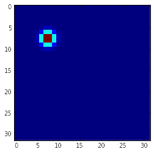

```
Second gaussian
```

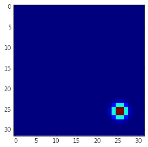

```python
values = np.exp(-np.sum(0.5 * (points_ - mean_)**2,axis=2))
print "First gaussian"
plt.imshow(values[0].reshape(32,32),interpolation='none')
plt.show()
print "Second gaussian"
plt.imshow(values[1].reshape(32,32),interpolation='none')
```

You can do this entire process in Theano with just some minor changes:

```python
shared_points = theano.shared(np.dstack(np.meshgrid(np.arange(cols),np.arange(rows))).reshape(n_hidden,2))
shared_mean = theano.shared(np.array(
    [[7.5,7.5],
     [25.5,25.5]],dtype=np.float32))

#points_ = points.reshape(1,1024,2)
points_ = shared_points.dimshuffle('x',0,1)
#mean_ = mean.reshape(2,1,2)
mean_ = shared_mean.dimshuffle(0,'x',1)

(points_ - mean_).eval().shape
```

```
(2, 1024, 2)
```

### Main takeaway

Numpy / Theano broadcasting. If you know what you are doing, it makes your code concise. If you don't get it, then other people's code is cryptic as hell.

To introduce constraints, we already have the (2, 1024) array we need (before we do any reshaping).

Essentially what is needed is to just calculate KL-divergence between any other 32x32 surface, and the new grid Gaussian surface we made.

```python
def kl_divergence(x,surfaces):
    return T.sum(x * (T.log(x) - T.log(surfaces)),axis = 1)
```

### Theano indexing

```python
nums = T.arange(10)[::-1]
nums.eval()
```

```
array([9, 8, 7, 6, 5, 4, 3, 2, 1, 0])
```

```python
nums[[2,1,3,5,6]].eval()
```

```
array([7, 8, 6, 4, 3])
```

```python
nums = T.eye(5)
nums.eval()
```

```
array([[ 1.,  0.,  0.,  0.,  0.],
       [ 0.,  1.,  0.,  0.,  0.],
       [ 0.,  0.,  1.,  0.,  0.],
       [ 0.,  0.,  0.,  1.,  0.],
       [ 0.,  0.,  0.,  0.,  1.]])
```

```python
nums[[2,1,3]].eval()
```

```
array([[ 0.,  0.,  1.,  0.,  0.],
       [ 0.,  1.,  0.,  0.,  0.],
       [ 0.,  0.,  0.,  1.,  0.]])
```

We have an array of (48,1024) gaussian surfaces. So to use the appropriate surface for the right phoneme, we simply do `values[phonemes]` (where `phonemes` is the phonemes of the corresponding frames